# Logistic Regression salary

pg606@scarletmail.rutgers.edu

2024-04-19

```r
library(ggplot2)
library(cowplot)
#library(regclass)
library(caret)
library(e1071)
library(pROC)
data <- read.csv("/Users/Prateekg/Documents/MVA/Salary_multiple_regression.csv", row.names=1)
data
```

```
##                                                      job_category
## AI Architect                              Machine Learning and AI
## AI Developer                              Machine Learning and AI
## AI Engineer                               Machine Learning and AI
## AI Scientist                              Machine Learning and AI
## Analytics Engineer                      Leadership and Management
## Applied Machine Learning Scientist        Machine Learning and AI
## Applied Scientist                       Data Science and Research
## AWS Data Architect                 Data Architecture and Modeling
## Azure Data Engineer                              Data Engineering
## BI Analyst                                   BI and Visualization
##                                    salary_currency employee_residence
## AI Architect                                   USD      United States
## AI Developer                                   EUR             France
## AI Engineer                                    USD     Czech Republic
## AI Scientist                                   USD              Ghana
## Analytics Engineer                             USD      United States
## Applied Machine Learning Scientist             USD      United States
## Applied Scientist                              USD      United States
## AWS Data Architect                             USD      United States
## Azure Data Engineer                            USD        Netherlands
## BI Analyst                                     USD      United States
##                                    experience_level employment_type
## AI Architect                                 Senior       Full-time
## AI Developer                                 Senior       Full-time
## AI Engineer                               Mid-level        Contract
## AI Scientist                              Mid-level       Full-time
## Analytics Engineer                        Mid-level       Full-time
## Applied Machine Learning Scientist        Mid-level       Full-time
## Applied Scientist                         Mid-level       Full-time
## AWS Data Architect                        Mid-level       Full-time
## Azure Data Engineer                          Senior       Full-time
## BI Analyst                                Mid-level       Full-time
##                                    work_setting company_location company_size
## AI Architect                             Remote    United States            M
## AI Developer                             Hybrid           France            M
## AI Engineer                              Remote           Canada            L
## AI Scientist                          In-person            Ghana            S
## Analytics Engineer                    In-person    United States            M
## Applied Machine Learning Scientist       Hybrid    United States            L
```

[output cut: 11 more lines]

```
## Applied Scientist                          High      2022 222200        222200
## AWS Data Architect                         High      2015 258000        258000
## Azure Data Engineer                         Low      2013 100000        100000
## BI Analyst                                 High      2014 160000        160000
##                                    salaryLevel
## AI Architect                                 1
## AI Developer                                 1
## AI Engineer                                  0
## AI Scientist                                 0
## Analytics Engineer                           0
## Applied Machine Learning Scientist           1
## Applied Scientist                            1
## AWS Data Architect                           1
## Azure Data Engineer                          0
## BI Analyst                                   1
```

```r
head(data) # you see data, but no column names
```

```
##                                                 job_category salary_currency
## AI Architect                         Machine Learning and AI             USD
## AI Developer                         Machine Learning and AI             EUR
## AI Engineer                          Machine Learning and AI             USD
## AI Scientist                         Machine Learning and AI             USD
## Analytics Engineer                 Leadership and Management             USD
## Applied Machine Learning Scientist   Machine Learning and AI             USD
##                                    employee_residence experience_level
## AI Architect                            United States           Senior
## AI Developer                                   France           Senior
## AI Engineer                            Czech Republic        Mid-level
## AI Scientist                                    Ghana        Mid-level
## Analytics Engineer                      United States        Mid-level
## Applied Machine Learning Scientist      United States        Mid-level
##                                    employment_type work_setting
## AI Architect                             Full-time       Remote
## AI Developer                             Full-time       Hybrid
## AI Engineer                               Contract       Remote
## AI Scientist                             Full-time    In-person
## Analytics Engineer                       Full-time    In-person
## Applied Machine Learning Scientist       Full-time       Hybrid
##                                    company_location company_size Salary_Level
## AI Architect                          United States            M         High
## AI Developer                                 France            M         High
## AI Engineer                                  Canada            L          Low
## AI Scientist                                  Ghana            S          Low
## Analytics Engineer                    United States            M          Low
## Applied Machine Learning Scientist    United States            L         High
##                                    work_year salary salary_in_usd salaryLevel
## AI Architect                            2020 305100        305100           1
## AI Developer                            2016 150000        161952           1
## AI Engineer                             2018  50000         50000           0
## AI Scientist                            2017  30000         30000           0
## Analytics Engineer                      2023 140000        140000           0
## Applied Machine Learning Scientist      2021 423000        423000           1
```

```r
## Data Cleansing and Prep
colnames(data) <- c("Job_Category", "salary_currency", "Employee_residence", "Experience_level", "Emp_type", "work_setting", "location", "company_size", "salary_Level","work_year","salary","salary_usd","salary_level")

head(data)
```

```
##                                                 Job_Category salary_currency
## AI Architect                         Machine Learning and AI             USD
## AI Developer                         Machine Learning and AI             EUR
## AI Engineer                          Machine Learning and AI             USD
## AI Scientist                         Machine Learning and AI             USD
## Analytics Engineer                 Leadership and Management             USD
## Applied Machine Learning Scientist   Machine Learning and AI             USD
##                                    Employee_residence Experience_level
## AI Architect                            United States           Senior
## AI Developer                                   France           Senior
## AI Engineer                            Czech Republic        Mid-level
## AI Scientist                                    Ghana        Mid-level
## Analytics Engineer                      United States        Mid-level
## Applied Machine Learning Scientist      United States        Mid-level
##                                     Emp_type work_setting      location
## AI Architect                       Full-time       Remote United States
## AI Developer                       Full-time       Hybrid        France
## AI Engineer                         Contract       Remote        Canada
## AI Scientist                       Full-time    In-person         Ghana
## Analytics Engineer                 Full-time    In-person United States
## Applied Machine Learning Scientist Full-time       Hybrid United States
##                                    company_size salary_Level work_year salary
## AI Architect                                  M         High      2020 305100
## AI Developer                                  M         High      2016 150000
## AI Engineer                                   L          Low      2018  50000
## AI Scientist                                  S          Low      2017  30000
## Analytics Engineer                            M          Low      2023 140000
## Applied Machine Learning Scientist            L         High      2021 423000
##                                    salary_usd salary_level
## AI Architect                           305100            1
## AI Developer                           161952            1
## AI Engineer                             50000            0
## AI Scientist                            30000            0
## Analytics Engineer                     140000            0
## Applied Machine Learning Scientist     423000            1
```

```r
str(data)
```

```
## 'data.frame':    10 obs. of  13 variables:
##  $ Job_Category      : chr  "Machine Learning and AI" "Machine Learning and AI" "Machine Learning and AI" "Machine Learning and AI" ...
##  $ salary_currency   : chr  "USD" "EUR" "USD" "USD" ...
##  $ Employee_residence: chr  "United States" "France" "Czech Republic" "Ghana" ...
##  $ Experience_level  : chr  "Senior" "Senior" "Mid-level" "Mid-level" ...
##  $ Emp_type          : chr  "Full-time" "Full-time" "Contract" "Full-time" ...
##  $ work_setting      : chr  "Remote" "Hybrid" "Remote" "In-person" ...
##  $ location          : chr  "United States" "France" "Canada" "Ghana" ...
##  $ company_size      : chr  "M" "M" "L" "S" ...
##  $ salary_Level      : chr  "High" "High" "Low" "Low" ...
##  $ work_year         : int  2020 2016 2018 2017 2023 2021 2022 2015 2013 2014
##  $ salary            : int  305100 150000 50000 30000 140000 423000 222200 258000 100000 160000
##  $ salary_usd        : int  305100 161952 50000 30000 140000 423000 222200 258000 100000 160000
##  $ salary_level      : int  1 1 0 0 0 1 1 1 0 1
```

```r
# DATA CLEANING

data[data == "?"] <- NA
data$Job_Category <- as.factor(data$Job_Category)
data$salary_currency <- as.factor(data$salary_currency)
data$Employee_residence <- as.factor(data$Employee_residence)
data$Experience_level<- as.factor(data$Experience_level)
data$Emp_type <- as.factor(data$Emp_type)
data$work_setting<- as.factor(data$work_setting)
data$location <- as.factor(data$location)
data$company_size <- as.factor(data$company_size)
data$salary_Level <- as.factor(data$salary_Level)
data$work_year<- as.factor(data$work_year)
data$salary <- as.factor(data$salary)
data$salary_usd <- as.factor(data$salary_usd)
data$salary_level <- as.factor(data$salary_level)

data$work_year <- as.numeric(as.character(data$work_year))
data$work_year <- cut(data$work_year, breaks = c(-Inf, 2015, Inf), labels = c("Before 2015", "After 2015"))

data$salary <- as.numeric(as.character(data$salary))
data$salary <- cut(data$salary, breaks = c(-Inf, 150000, Inf), labels = c("Less salary", "More salary"))

data$salary_usd <- as.numeric(as.character(data$salary_usd))
data$salary_usd<- cut(data$salary_usd, breaks = c(-Inf, 150000, Inf), labels = c("Less salary", "More salary"))


str(data)
```

```
## 'data.frame':    10 obs. of  13 variables:
##  $ Job_Category      : Factor w/ 6 levels "BI and Visualization",..: 6 6 6 6 5 6 4 2 3 1
##  $ salary_currency   : Factor w/ 2 levels "EUR","USD": 2 1 2 2 2 2 2 2 2 2
##  $ Employee_residence: Factor w/ 5 levels "Czech Republic",..: 5 2 1 3 5 5 5 5 4 5
##  $ Experience_level  : Factor w/ 2 levels "Mid-level","Senior": 2 2 1 1 1 1 1 1 2 1
##  $ Emp_type          : Factor w/ 2 levels "Contract","Full-time": 2 2 1 2 2 2 2 2 2 2
##  $ work_setting      : Factor w/ 3 levels "Hybrid","In-person",..: 3 1 3 2 2 1 2 3 1 2
##  $ location          : Factor w/ 5 levels "Canada","France",..: 5 2 1 3 5 5 5 5 4 5
##  $ company_size      : Factor w/ 3 levels "L","M","S": 2 2 1 3 2 1 1 1 1 2
##  $ salary_Level      : Factor w/ 2 levels "High","Low": 1 1 2 2 2 1 1 1 2 1
##  $ work_year         : Factor w/ 2 levels "Before 2015",..: 2 2 2 2 2 2 2 1 1 1
##  $ salary            : Factor w/ 2 levels "Less salary",..: 2 1 1 1 1 2 2 2 1 2
##  $ salary_usd        : Factor w/ 2 levels "Less salary",..: 2 2 1 1 1 2 2 2 1 2
##  $ salary_level      : Factor w/ 2 levels "0","1": 2 2 1 1 1 2 2 2 1 2
```

#Model Development

```r
## Exploratory Analysis

xtabs(~ salary_level + Job_Category, data=data)
```

```
##             Job_Category
## salary_level BI and Visualization Data Architecture and Modeling
##            0                    0                              0
##            1                    1                              1
##             Job_Category
## salary_level Data Engineering Data Science and Research
##            0                1                         0
##            1                0                         1
##             Job_Category
## salary_level Leadership and Management Machine Learning and AI
##            0                         1                       2
##            1                         0                       3
```

```r
xtabs(~ salary_level + salary_currency, data=data)
```

```
##             salary_currency
## salary_level EUR USD
##            0   0   4
##            1   1   5
```

```r
xtabs(~ salary_level + Employee_residence, data=data)
```

```
##             Employee_residence
## salary_level Czech Republic France Ghana Netherlands United States
##            0              1      0     1           1             1
##            1              0      1     0           0             5
```

```r
xtabs(~ salary_level + Experience_level, data=data)
```

```
##             Experience_level
## salary_level Mid-level Senior
##            0         3      1
##            1         4      2
```

```r
xtabs(~ salary_level + Emp_type, data=data)
```

```
##             Emp_type
## salary_level Contract Full-time
##            0        1         3
##            1        0         6
```

```r
xtabs(~ salary_level + work_setting, data=data)
```

```
##             work_setting
## salary_level Hybrid In-person Remote
##            0      1         2      1
##            1      2         2      2
```

```r
xtabs(~ salary_level + location, data=data)
```

```
##             location
## salary_level Canada France Ghana Netherlands United States
##            0      1      0     1           1             1
##            1      0      1     0           0             5
```

```r
xtabs(~ salary_level + company_size, data=data)
```

```
##             company_size
## salary_level L M S
##            0 2 1 1
##            1 3 3 0
```

```r
xtabs(~ salary_level + salary_Level, data=data)
```

```
##             salary_Level
## salary_level High Low
##            0    0   4
##            1    6   0
```

```r
xtabs(~ salary_level + work_year, data=data)
```

```
##             work_year
## salary_level Before 2015 After 2015
##            0           1          3
##            1           2          4
```

```r
xtabs(~ salary_level + salary, data=data)
```

```
##             salary
## salary_level Less salary More salary
##            0           4           0
##            1           1           5
```

```r
xtabs(~ salary_level + salary_usd, data=data)
```

```
##             salary_usd
## salary_level Less salary More salary
##            0           4           0
##            1           0           6
```

```r
logistic_simple <- glm(salary_level ~ Experience_level, data=data, family="binomial")
summary(logistic_simple)
```

```
##
## Call:
## glm(formula = salary_level ~ Experience_level, family = "binomial",
##     data = data)
##
## Coefficients:
##                        Estimate Std. Error z value Pr(>|z|)
## (Intercept)              0.2877     0.7638   0.377    0.706
## Experience_levelSenior   0.4055     1.4434   0.281    0.779
##
## (Dispersion parameter for binomial family taken to be 1)
##
##     Null deviance: 13.46  on 9  degrees of freedom
## Residual deviance: 13.38  on 8  degrees of freedom
## AIC: 17.38
##
## Number of Fisher Scoring iterations: 4
```

Insights-

The Intercept represents the log odds of the baseline group (Mid-level experience) having a salary level of 1 (presumably higher salary) versus 0 (lower salary).

AIC is used as a measure of the model’s goodness of fit, where lower values indicate a better fit. The AIC value here is 17.38. The p-values associated with each coefficient indicate whether they are significantly different from zero. In this case, neither the Intercept nor the coefficient for Experience_levelSenior are statistically significant (p > 0.05), suggesting that there may not be a significant relationship between experience level and salary level based on this simple model.

# Model acceptance

```r
Less_salary_level.log.odds <- log(4/ 3)
Less_salary_level.log.odds
```

```
## [1] 0.2876821
```

```r
# Now you know how these are calculated
more_salary_level.log.odds.ratio <- log((2 / 1) / (4/3))
more_salary_level.log.odds.ratio
```

```
## [1] 0.4054651
```

The more_salary_level.log.odds.ratio represents the log odds ratio of having a higher salary level compared to a lower one. The calculated value is approximately 0.4055.

# PREDICTION

```r
predicted.data <- data.frame(probability.of.hd=logistic_simple$fitted.values,Experience_level=data$Experience_level)
predicted.data
```

```
##                                    probability.of.hd Experience_level
## AI Architect                               0.6666667           Senior
## AI Developer                               0.6666667           Senior
## AI Engineer                                0.5714286        Mid-level
## AI Scientist                               0.5714286        Mid-level
## Analytics Engineer                         0.5714286        Mid-level
## Applied Machine Learning Scientist         0.5714286        Mid-level
## Applied Scientist                          0.5714286        Mid-level
## AWS Data Architect                         0.5714286        Mid-level
## Azure Data Engineer                        0.6666667           Senior
## BI Analyst                                 0.5714286        Mid-level
```

```r
xtabs(~ probability.of.hd + Experience_level, data=predicted.data)
```

```
##                    Experience_level
## probability.of.hd   Mid-level Senior
##   0.571428571428572         7      0
##   0.666666666666622         0      3
```

```r
logistic <- glm(salary_level ~ ., data=data, family="binomial")
summary(logistic)
```

```
##
## Call:
## glm(formula = salary_level ~ ., family = "binomial", data = data)
##
## Coefficients: (15 not defined because of singularities)
##                                              Estimate Std. Error z value
## (Intercept)                                 2.457e+01  2.269e+05       0
## Job_CategoryData Architecture and Modeling  5.095e-08  1.853e+05       0
## Job_CategoryData Engineering                1.103e-06  3.706e+05       0
## Job_CategoryData Science and Research       1.110e-10  1.853e+05       0
## Job_CategoryLeadership and Management      -4.913e+01  1.853e+05       0
## Job_CategoryMachine Learning and AI        -4.496e-10  1.853e+05       0
## salary_currencyUSD                         -4.913e+01  2.620e+05       0
## Employee_residenceFrance                           NA         NA      NA
## Employee_residenceGhana                     5.741e-14  1.853e+05       0
## Employee_residenceNetherlands                      NA         NA      NA
## Employee_residenceUnited States             4.913e+01  1.853e+05       0
## Experience_levelSenior                     -1.104e-06  1.853e+05       0
## Emp_typeFull-time                                  NA         NA      NA
## work_settingIn-person                              NA         NA      NA
## work_settingRemote                                 NA         NA      NA
## locationFrance                                     NA         NA      NA
## locationGhana                                      NA         NA      NA
## locationNetherlands                                NA         NA      NA
## locationUnited States                              NA         NA      NA
## company_sizeM                                      NA         NA      NA
## company_sizeS                                      NA         NA      NA
## salary_LevelLow                                    NA         NA      NA
## work_yearAfter 2015                                NA         NA      NA
## salaryMore salary                                  NA         NA      NA
## salary_usdMore salary                              NA         NA      NA
##                                            Pr(>|z|)
## (Intercept)                                       1
## Job_CategoryData Architecture and Modeling        1
## Job_CategoryData Engineering                      1
## Job_CategoryData Science and Research             1
## Job_CategoryLeadership and Management             1
## Job_CategoryMachine Learning and AI               1
## salary_currencyUSD                                1
## Employee_residenceFrance                         NA
```

[output cut: 10 more lines]

```
## locationUnited States                            NA
## company_sizeM                                    NA
## company_sizeS                                    NA
## salary_LevelLow                                  NA
## work_yearAfter 2015                              NA
## salaryMore salary                                NA
## salary_usdMore salary                            NA
##
## (Dispersion parameter for binomial family taken to be 1)
##
##     Null deviance: 1.3460e+01  on 9  degrees of freedom
## Residual deviance: 4.2867e-10  on 0  degrees of freedom
## AIC: 20
##
## Number of Fisher Scoring iterations: 23
```

The probabilities range from approximately 0.57 to 0.67 for different observations.

Individuals categorized as “Mid-level” have a predicted probability of 0.5714286, while individuals categorized as “Senior” have a predicted probability of 0.6666667.

#Residual Analysis

```r
## Now calculate the overall "Pseudo R-squared" and its p-value
ll.null <- logistic$null.deviance/-2
ll.proposed <- logistic$deviance/-2
(ll.null - ll.proposed) / ll.null
```

```
## [1] 1
```

```r
## The p-value for the R^2
1 - pchisq(2*(ll.proposed - ll.null), df=(length(logistic$coefficients)-1))
```

```
## [1] 0.9579177
```

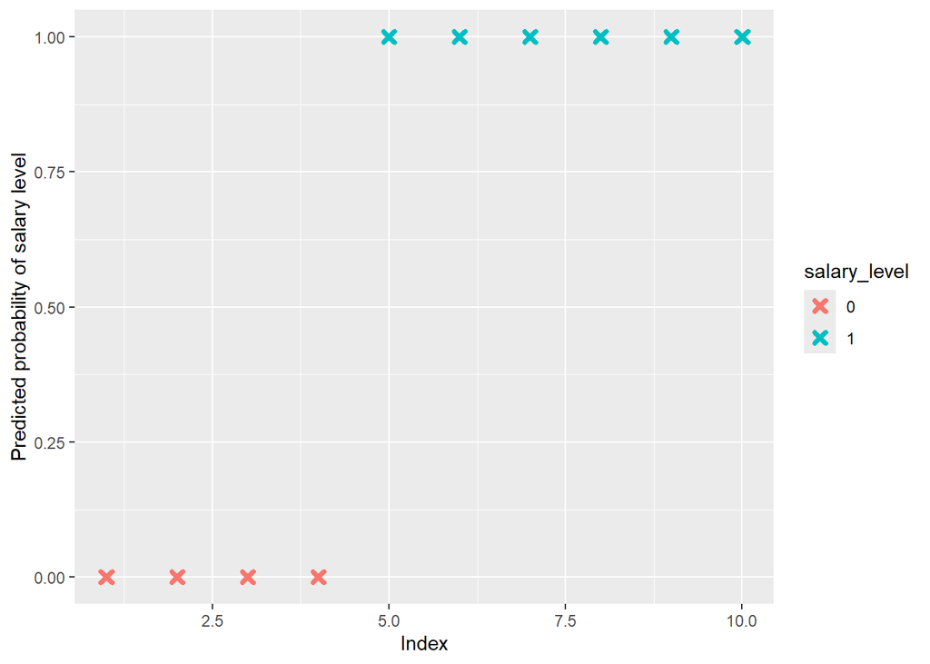

```r
predicted.data <- data.frame(probability.of.hd=logistic$fitted.values,salary_level=data$salary_level)
predicted.data <- predicted.data[order(predicted.data$probability.of.hd, decreasing=FALSE),]
predicted.data$rank <- 1:nrow(predicted.data)

ggplot(data=predicted.data, aes(x=rank, y=probability.of.hd)) +
  geom_point(aes(color=salary_level), alpha=1, shape=4, stroke=2) +
  xlab("Index") +
  ylab("Predicted probability of salary level")
```

```r
pdata <- predict(logistic,newdata=data,type="response" )
pdata
```

```
##                       AI Architect                       AI Developer
##                       1.000000e+00                       1.000000e+00
##                        AI Engineer                       AI Scientist
##                       2.143345e-11                       2.143345e-11
##                 Analytics Engineer Applied Machine Learning Scientist
##                       2.143345e-11                       1.000000e+00
##                  Applied Scientist                 AWS Data Architect
##                       1.000000e+00                       1.000000e+00
##                Azure Data Engineer                         BI Analyst
##                       2.143345e-11                       1.000000e+00
## attr(,"non-estim")
##                       AI Architect                       AI Developer
##                                  1                                  2
##                        AI Engineer                       AI Scientist
##                                  3                                  4
##                 Analytics Engineer Applied Machine Learning Scientist
##                                  5                                  6
##                  Applied Scientist                 AWS Data Architect
##                                  7                                  8
##                Azure Data Engineer                         BI Analyst
##                                  9                                 10
```

```r
data$salary_level
```

```
##  [1] 1 1 0 0 0 1 1 1 0 1
## Levels: 0 1
```

```r
pdataF <- as.factor(ifelse(test=as.numeric(pdata>0.5) == 0, yes="0", no="1"))
```

The pseudo R-squared value is calculated to be 1, indicating that the model explains all the variance in the data. However, such a high value may suggest overfitting or other issues with the model.

#Model Accuracy

```r
confusionMatrix(pdataF, data$salary_level)
```

```
## Confusion Matrix and Statistics
##
##           Reference
## Prediction 0 1
##          0 4 0
##          1 0 6
##
##                Accuracy : 1
##                  95% CI : (0.6915, 1)
##     No Information Rate : 0.6
##     P-Value [Acc > NIR] : 0.006047
##
##                   Kappa : 1
##
##  Mcnemar's Test P-Value : NA
##
##             Sensitivity : 1.0
##             Specificity : 1.0
##          Pos Pred Value : 1.0
##          Neg Pred Value : 1.0
##              Prevalence : 0.4
##          Detection Rate : 0.4
##    Detection Prevalence : 0.4
##       Balanced Accuracy : 1.0
##
##        'Positive' Class : 0
##
```

```r
# From pROC
roc(data$salary_level,logistic$fitted.values,plot=TRUE)
```

```
##
## Call:
## roc.default(response = data$salary_level, predictor = logistic$fitted.values,     plot = TRUE)
##
## Data: logistic$fitted.values in 4 controls (data$salary_level 0) < 6 cases (data$salary_level 1).
## Area under the curve: 1
```

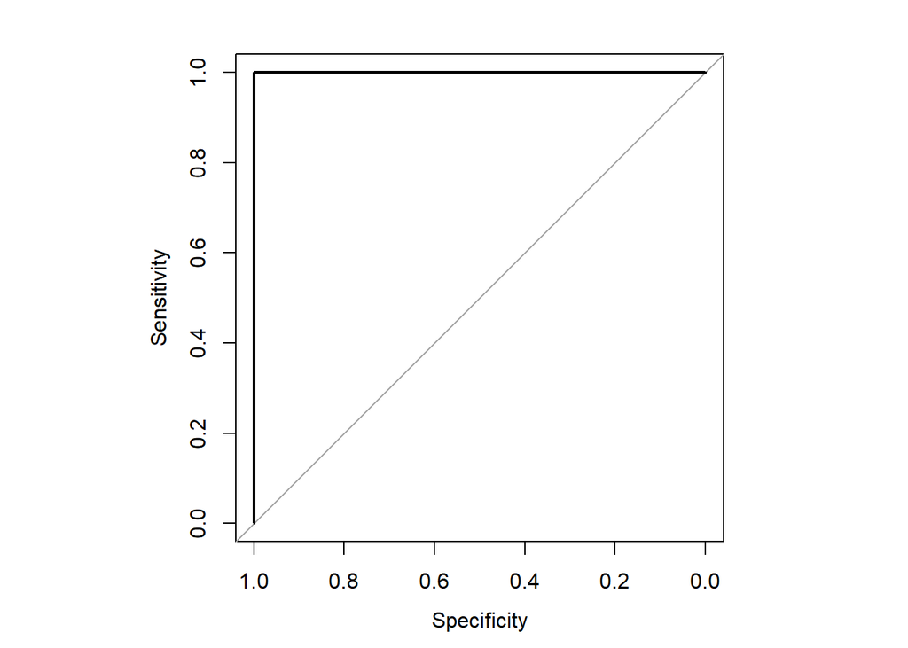

```
##
## Call:
## roc.default(response = data$salary_level, predictor = logistic$fitted.values,     plot = TRUE)
##
## Data: logistic$fitted.values in 4 controls (data$salary_level 0) < 6 cases (data$salary_level 1).
## Area under the curve: 1
```

```r
par(pty = "s")
roc(data$salary_level,logistic$fitted.values,plot=TRUE)
```

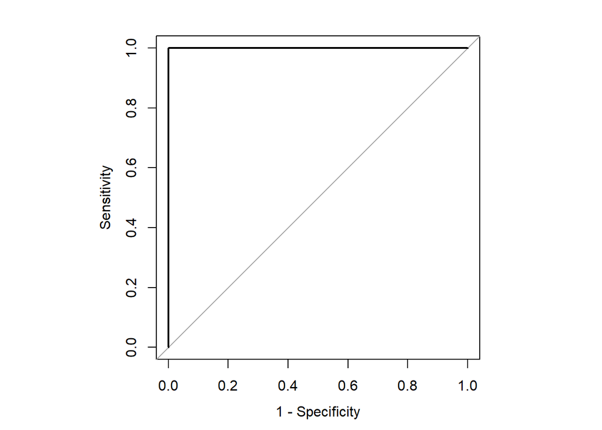

```
##
## Call:
## roc.default(response = data$salary_level, predictor = logistic$fitted.values,     plot = TRUE, legacy.axes = TRUE)
##
## Data: logistic$fitted.values in 4 controls (data$salary_level 0) < 6 cases (data$salary_level 1).
## Area under the curve: 1
```

```r
roc(data$salary_level,logistic$fitted.values,plot=TRUE, legacy.axes=TRUE)
```

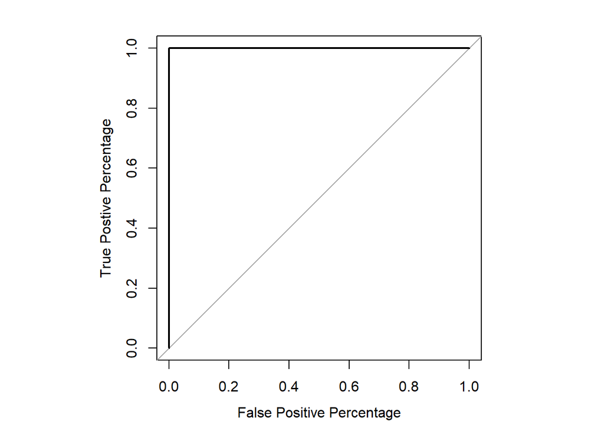

```
##
## Call:
## roc.default(response = data$salary_level, predictor = logistic$fitted.values,     plot = TRUE, legacy.axes = TRUE, xlab = "False Positive Percentage",     ylab = "True Postive Percentage")
##
## Data: logistic$fitted.values in 4 controls (data$salary_level 0) < 6 cases (data$salary_level 1).
## Area under the curve: 1
```

```r
roc(data$salary_level,logistic$fitted.values,plot=TRUE, legacy.axes=TRUE, xlab="False Positive Percentage", ylab="True Postive Percentage")
```

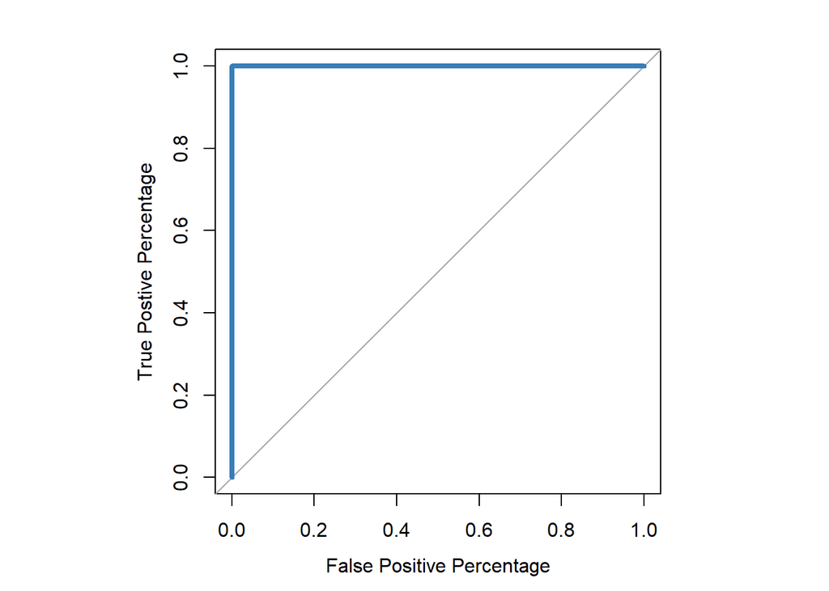

```
##
## Call:
## roc.default(response = data$salary_level, predictor = logistic$fitted.values,     plot = TRUE, legacy.axes = TRUE, xlab = "False Positive Percentage",     ylab = "True Postive Percentage", col = "#377eb8", lwd = 4)
##
## Data: logistic$fitted.values in 4 controls (data$salary_level 0) < 6 cases (data$salary_level 1).
## Area under the curve: 1
```

```r
roc(data$salary_level,logistic$fitted.values,plot=TRUE, legacy.axes=TRUE, xlab="False Positive Percentage", ylab="True Postive Percentage", col="#377eb8", lwd=4)
```

```r
roc(data$salary_level,logistic$fitted.values,plot=TRUE, legacy.axes=TRUE, xlab="False Positive Percentage", ylab="True Postive Percentage", col="#377eb8", lwd=4)
```

```
##
## Call:
## roc.default(response = data$salary_level, predictor = logistic$fitted.values,     plot = TRUE, legacy.axes = TRUE, xlab = "False Positive Percentage",     ylab = "True Postive Percentage", col = "#377eb8", lwd = 4)
##
## Data: logistic$fitted.values in 4 controls (data$salary_level 0) < 6 cases (data$salary_level 1).
## Area under the curve: 1
```

```r
## If we want to find out the optimal threshold we can store the
## data used to make the ROC graph in a variable...
roc.info <- roc(data$salary_level, logistic$fitted.values, legacy.axes=TRUE)
str(roc.info)
```

[output not shown]

```r
## tpp = true positive percentage
## fpp = false positive precentage
roc.df <- data.frame(tpp=roc.info$sensitivities*100, fpp=(1 - roc.info$specificities)*100,thresholds=roc.info$thresholds)
roc.df
```

```
##   tpp fpp   thresholds
## 1 100 100         -Inf
## 2 100  75 2.143345e-11
## 3 100  50 2.143345e-11
## 4 100  25 2.143345e-11
## 5 100   0 5.000000e-01
## 6   0   0          Inf
```

```r
head(roc.df)
```

```
##   tpp fpp   thresholds
## 1 100 100         -Inf
## 2 100  75 2.143345e-11
## 3 100  50 2.143345e-11
## 4 100  25 2.143345e-11
## 5 100   0 5.000000e-01
## 6   0   0          Inf
```

```r
tail(roc.df)
```

```
##   tpp fpp   thresholds
## 1 100 100         -Inf
## 2 100  75 2.143345e-11
## 3 100  50 2.143345e-11
## 4 100  25 2.143345e-11
## 5 100   0 5.000000e-01
## 6   0   0          Inf
```

```r
roc.df[roc.df$tpp > 60 & roc.df$tpp < 80,]
```

```
## [1] tpp        fpp        thresholds
## <0 rows> (or 0-length row.names)
```

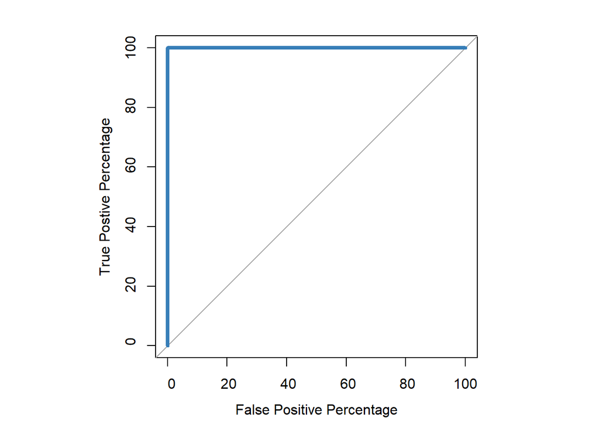

```
##
## Call:
## roc.default(response = data$salary_level, predictor = logistic$fitted.values,     percent = TRUE, plot = TRUE, legacy.axes = TRUE, xlab = "False Positive Percentage",     ylab = "True Postive Percentage", col = "#377eb8", lwd = 4)
##
## Data: logistic$fitted.values in 4 controls (data$salary_level 0) < 6 cases (data$salary_level 1).
## Area under the curve: 100%
```

```r
roc(data$salary_level,logistic$fitted.values,plot=TRUE, legacy.axes=TRUE, xlab="False Positive Percentage", ylab="True Postive Percentage", col="#377eb8", lwd=4, percent=TRUE)
```

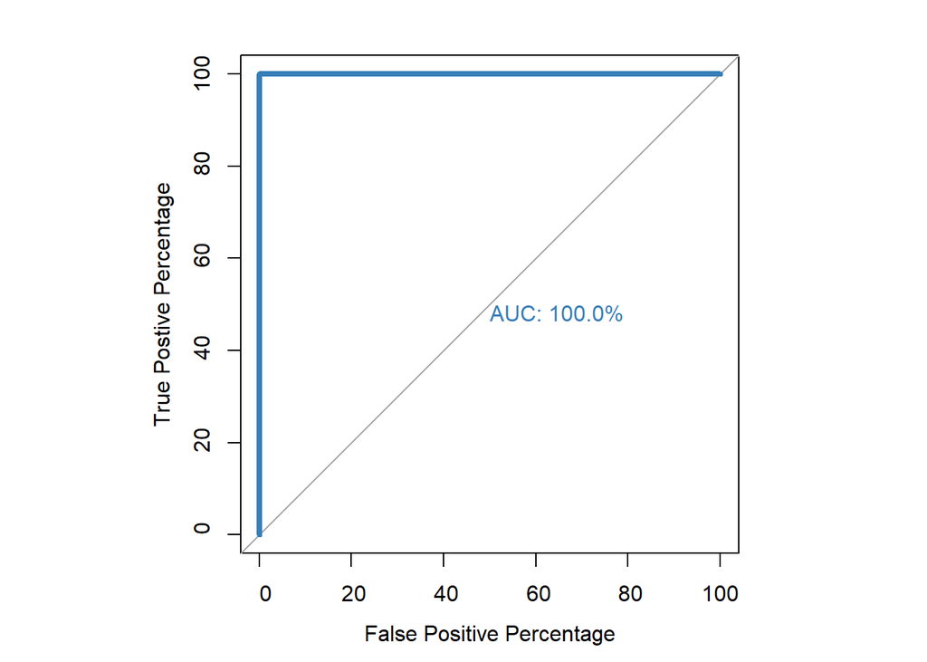

```
##
## Call:
## roc.default(response = data$salary_level, predictor = logistic$fitted.values,     percent = TRUE, plot = TRUE, legacy.axes = TRUE, xlab = "False Positive Percentage",     ylab = "True Postive Percentage", col = "#377eb8", lwd = 4,     print.auc = TRUE)
##
## Data: logistic$fitted.values in 4 controls (data$salary_level 0) < 6 cases (data$salary_level 1).
## Area under the curve: 100%
```

```r
roc(data$salary_level,logistic$fitted.values,plot=TRUE, legacy.axes=TRUE, xlab="False Positive Percentage", ylab="True Postive Percentage", col="#377eb8", lwd=4, percent=TRUE, print.auc=TRUE)
```

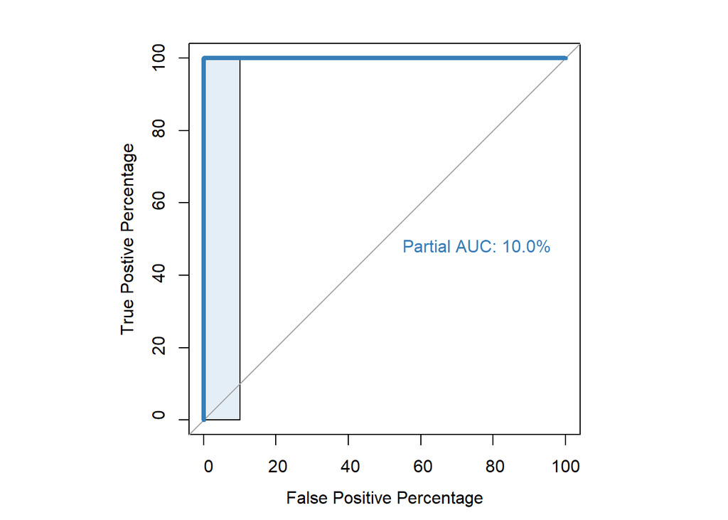

```
##
## Call:
## roc.default(response = data$salary_level, predictor = logistic$fitted.values,     percent = TRUE, plot = TRUE, legacy.axes = TRUE, xlab = "False Positive Percentage",     ylab = "True Postive Percentage", col = "#377eb8", lwd = 4,     print.auc = TRUE, partial.auc = c(100, 90), auc.polygon = TRUE…
##
## Data: logistic$fitted.values in 4 controls (data$salary_level 0) < 6 cases (data$salary_level 1).
## Partial area under the curve (specificity 100%-90%): 10%
```

```r
roc(data$salary_level,logistic$fitted.values,plot=TRUE, legacy.axes=TRUE, xlab="False Positive Percentage", ylab="True Postive Percentage", col="#377eb8", lwd=4, percent=TRUE, print.auc=TRUE, partial.auc=c(100, 90), auc.polygon = TRUE, auc.polygon.col = "#377eb822", print.auc.x=45)
```

```r
# Lets do two roc plots to understand which model is better
roc(data$salary_level, logistic_simple$fitted.values, plot=TRUE, legacy.axes=TRUE, percent=TRUE, xlab="False Positive Percentage", ylab="True Postive Percentage", col="#377eb8", lwd=4, print.auc=TRUE)
```

```
##
## Call:
## roc.default(response = data$salary_level, predictor = logistic_simple$fitted.values,     percent = TRUE, plot = TRUE, legacy.axes = TRUE, xlab = "False Positive Percentage",     ylab = "True Postive Percentage", col = "#377eb8", lwd = 4,     print.auc = TRUE)
##
## Data: logistic_simple$fitted.values in 4 controls (data$salary_level 0) < 6 cases (data$salary_level 1).
## Area under the curve: 54.17%
```

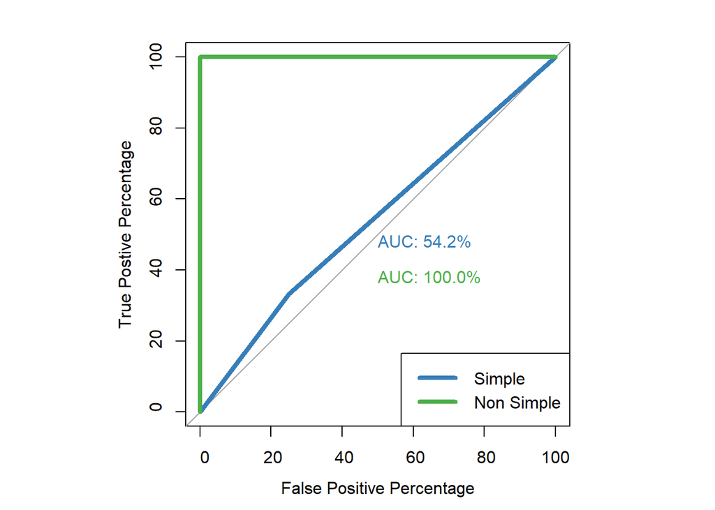

```r
# Lets add the other graph
plot.roc(data$salary_level, logistic$fitted.values, percent=TRUE, col="#4daf4a", lwd=4, print.auc=TRUE, add=TRUE, print.auc.y=40)
legend("bottomright", legend=c("Simple", "Non Simple"), col=c("#377eb8", "#4daf4a"), lwd=4)
```

There are 4 true negatives (predicted salary level 0 and actual salary level 0) and 6 true positives (predicted salary level 1 and actual salary level 1).

There are no false positives or false negatives, indicating perfect accuracy.

The area under the ROC curve (AUC) is a measure of the model’s discriminatory power. An AUC of 1 indicates a perfect classifier, while 0.5 suggests a random classifier.

The AUC value for the second model is 54.17%, which is significantly lower than the AUC of the current model (100%).